# Data Integrity: A Study

Joshua Bennett

Washington State University

November 10, 2020

Abstract

In this article we discuss a Data Set to try to expose data that isn’t in line with the norm, and exrapolate the possible reasons for the data inaccuracies.

Data Integrity is a critical part of Data Analysis. It is what ensures recoverability and searchability, as well as traceability and connectivity. Protecting the validity and accuracy of the data also increases stability and performance while improving reusability and maintainability. Data Integrity can be compromised in several different ways. Physical compromise of the device, bugs/viruses, transfer errors(unintended alterations to the data), and Human error(malicious or not). This report will be looking at mainly the last two categories of different ways it can compromised. Transfer errors, and Human error.

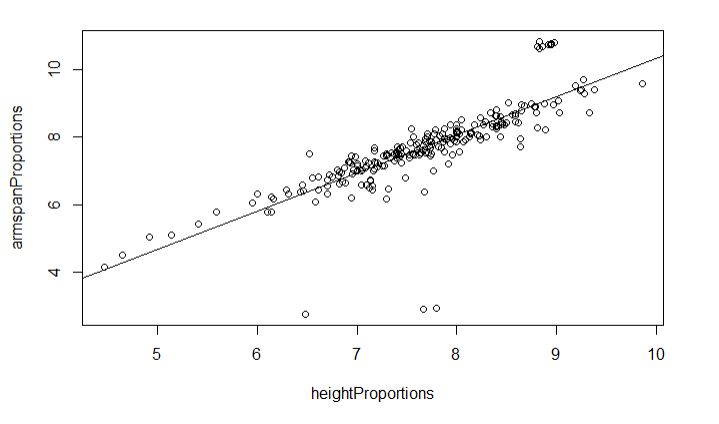

This is an example of outliers in the data

[figure not shown]

My primary research question is looking for outliers in the data set using the Vitruvian Man data proportions as reference data.

Given the Vitruvian man data, compare their arm spans to their height proportion to find issues in the data.

Are there discrepancies on both sides?

This data was collected by hand by around 30 students. It was taken from the family and friends of the students in the 419 Multivariate Statistics course at Washington State University. The data was recorded in early September during the Covid-19 Pandemic and because of this was harder than normal to acquire reliable data. The data gathered is focusing on bodily proportions but other data was taken as well, such as eye color and age. This data was chosen due to the ability for it to be taken easily and efficiently by the student in the class. The method of Acquiring the data was through a handout that was created by the students and could be given to a subject to fill out with descriptions of their proportions. It was then put into an excel document and transferred to a .txt file to be accessed and analyzed in RStudio.

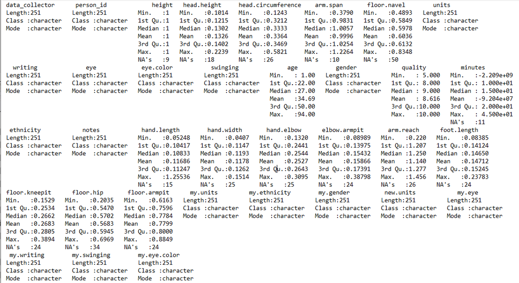

This is a summary of the Data Set that was used for this analysis

Using the Viruvian man Data, We created a Proportion Data Frame that we used to convert the original Measure Data to give us a general example of what a persons proportions should be. This is the covariate being analyzed divided by the height of the person. This gives us a number that we can compare to the Viruvian man data and if they are off by a significant margin we know there is a discrepancy. First we took the proportion data and created a plot of the height and headheight categories. Showing us the original anomalies, then created another plot that showed the arm span and height categories.

Using the methods described in the Summary Statistics of Data section, we can see that although there is a small sample size the P test for the Suspect(long) arm span data is well below 5%. Using this we can reject the Null Hypothesis. This makes the test extremely credible. There was something wrong about this data. If you multiply these values by 2.54 you don’t get a value anywhere close to what you would expect if it was a conversion error between centimeters and inches. The Arm Span is for this does not match up with expected values.

The plot charts also clearly show the outliers.

The beginning of the Data Provenance would be the method of collection collected. For my Data Collection personally, it was collected through my immediate family, my Wife, my Daughter, and my Son. I then created and sent out a Handout with all the necessary data for whoever is sent it to. They then filled out their data and sent it back to me via email. This precaution was due to the Covid-19 Pandemic. After all the data was received, it was given to our instructor. He then took that data and combined it into a much larger Data Set that we could Analyze with much more efficiency. The functions that are used to manipulate the data are located at the top of this document, as well as in the Functions folder on GitHub. I then organized the data by using the Viruvian Man Data, changing my main Data Frame from the measure.DF to Proportions.DF. This took only columns that were affected by height and divided them by the height. This gave me numbers that could be checked against the averages found by the Viruvian Man Data. I also cached the final.measure data set to a local hard drive to cut down on access times. The original version of measure.txt had a significant number of missing values and the Inches and CMs weren’t converted. I had originally created a method called convert_cm_in that took that data set and changed the data from CM to inches. We were then provided a document that did that already, so the method was unneeded. The Final.Measure Data set was made up of: the name of the data Collector, which is the student in the class who is collecting the data. The Height, which in my case was in inches, from the ground to the top of the subjects head. The Head Height, which is the height of the head from chin to top of the head. The head Circumference, which is the measure around the subjects head. The Arm Span, Which is the measurement from tip of finger to tip of finger with the subjects arms outstreched. The Floor to Navel measurement, distance from the Floor to the subjects navel. The Hand Length, The length from the bottom of the palm to tip of finger. The hand Width, The length of the hand at its widest point. The Hand to Elbow, the length from the elbow to tip of the finger. The Reach, how far the subject can reach towards the sky. The foot Length, The length of the subjects foot. The knee pit to floor, the length from the kneee pit to the floor. The hip to floor, the length from your hip to the ground. The armpit to floor, length from subjects armpit to the ground. The Dominant writing hand, The hand the subject uses to write. The Dominant Eye, The subjects dominant Eye, use the ocular dominance test to find this. The Eye color, color of the subjects eye. The dominant method of swinging a club, Is the subject a right or left handed swing. The Age, The subjects Age. The Gender, the subjects Gender the Ethnicity, the subjects Ethnicity. The Quality, the Quality of the subjects measurements. The minutes, length of time to record the information. The notes, any additional information the subject or collector decided to add.

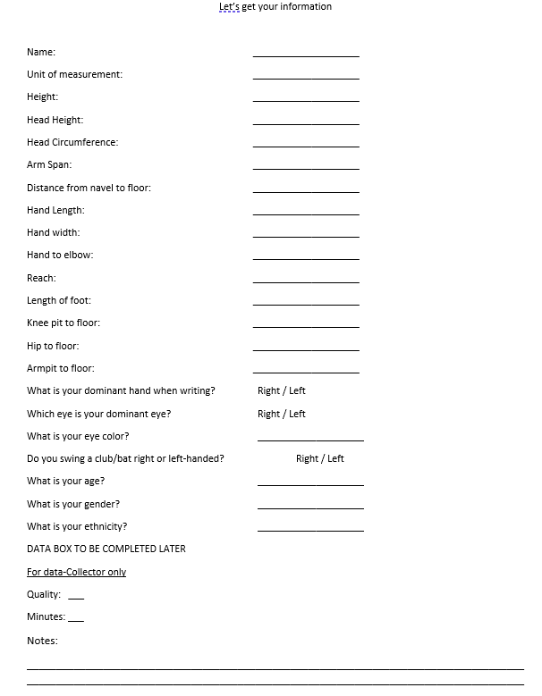

Below is the necessary functions and libraries required to run the code referenced in this document.

```r
library(devtools);       # required for source_url
path.humanVerseWSU = "https://raw.githubusercontent.com/MonteShaffer/humanVerseWSU/"
source_url( paste0(path.humanVerseWSU,"master/misc/functions-project-measure.R") );
convert_cm_in = function(cm){
  cm_inch = round( cm / 2.54, 2 )
  return(paste(cm_inch, "cm"))
}


VirtuvianMAn = function(input, input2)
  {
    return (input/input2)
  }
```

Below is the code to load the data and prepare it for analysis.

```r
path.project = "C:/Users/Galac/Desktop/git419/Stats419_FALL2020/Proj1/"

path.to.data = "C:/Users/Galac/Desktop/stats 419/";
measure = utils::read.csv( paste0(path.to.data, "final.measure.txt"), header=TRUE, quote="", sep="|");
#path.github = "https://raw.githubusercontent.com/this-IS-YOUR-PATH-TO-GITHUB/";
#source_url( paste0(path.github,"master/functions/functions-project-measure.R") );
# this is your function

measure.df <- measure

measureNAremoved= na.omit(measure.df)
```

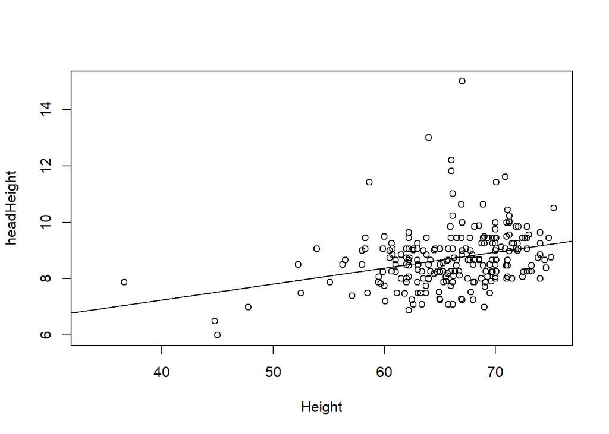

```r
proportion.df = measure.df

Height = measure.df$height
headHeight = measure.df$head.height

plot(Height, headHeight )
reg.n = lm(headHeight ~ Height)
abline(reg.n)


abline(reg.n)
proportion.df[,c(3:7, 19:27)] = proportion.df[,c(3:7, 19:27)]/proportion.df$height

proportion.df = measure.df
proportion.df[,c(3:7, 19:27)] = proportion.df[,c(3:7, 19:27)]/proportion.df$height

ArmSpanAverageProportion= VirtuvianMAn(measure.df$arm.span,measure.df$head.height)
HeightAverageProportion = VirtuvianMAn(measure.df$height, measure.df$head.height)

reg.n = lm(ArmSpanAverageProportion ~ HeightAverageProportion)
abline(reg.n)
```

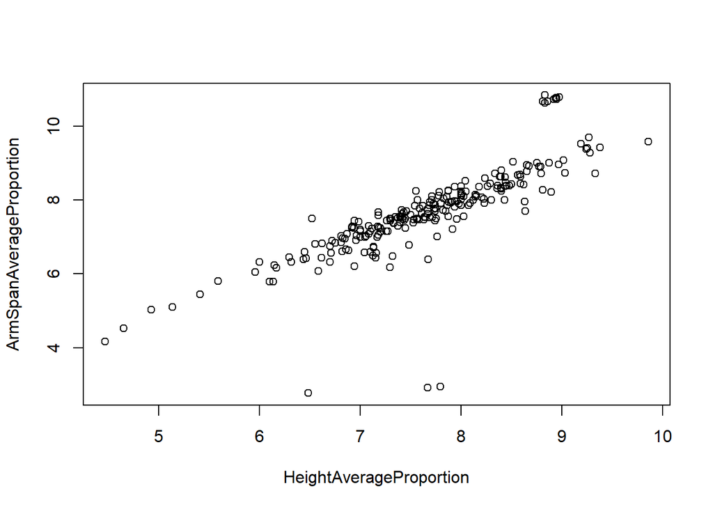

```r
plot(HeightAverageProportion, ArmSpanAverageProportion)
```

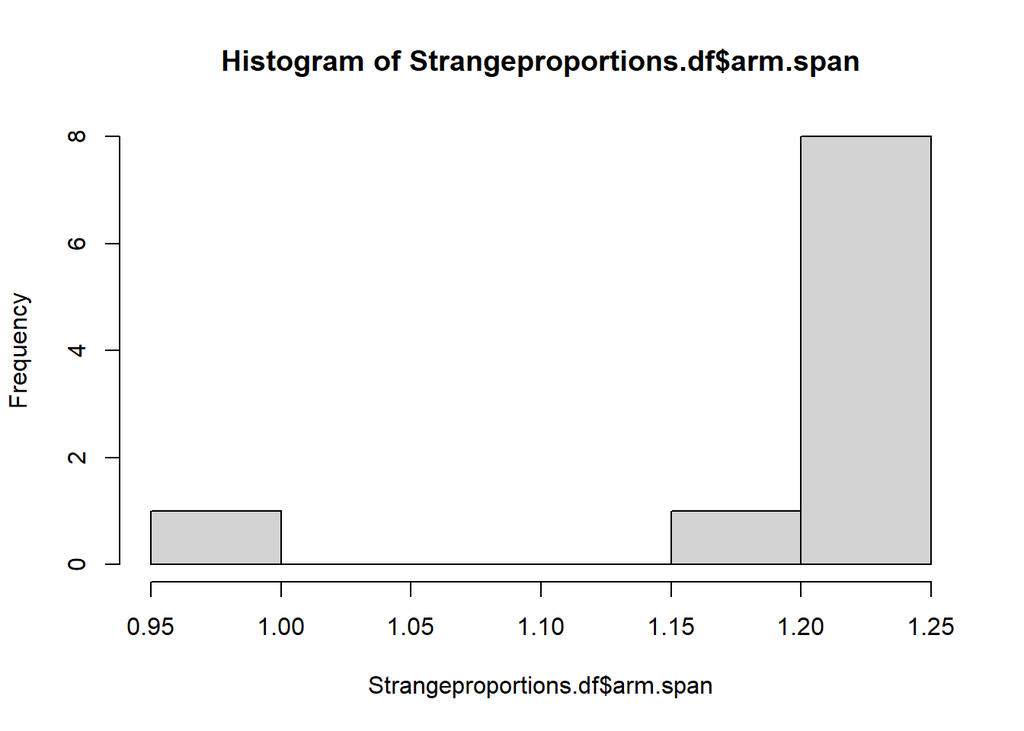

```r
reg.n = lm(ArmSpanAverageProportion ~ HeightAverageProportion)

Strangeproportions.df = proportion.df[proportion.df$data_collector == "c51267de031fb6d879a8abf25d260269", ]
#headheight should be around .14
#armSpan should be around .96
Correctproportions.df = proportion.df[proportion.df$data_collector == "fd36e2b3ec59dbd996587454cbb59725", ]

smallerProportions.df = proportion.df[proportion.df$data_collector ==   "5a2f371a934f22dffcf1e994cb6eca40", ]
smallerProportions1.df = smallerProportions.df[-1,]
smallerProportions2.df = smallerProportions1.df[-1,]

Correctproportions1.df = Correctproportions.df[-1,]
#Correctproportions1.df

hist(Strangeproportions.df$arm.span)
```

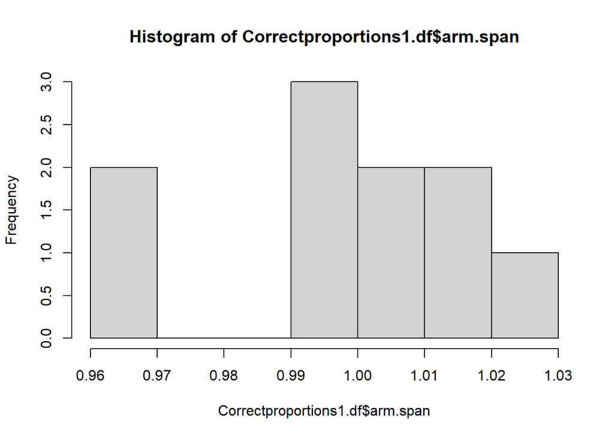

```r
hist(Correctproportions1.df$arm.span)
```

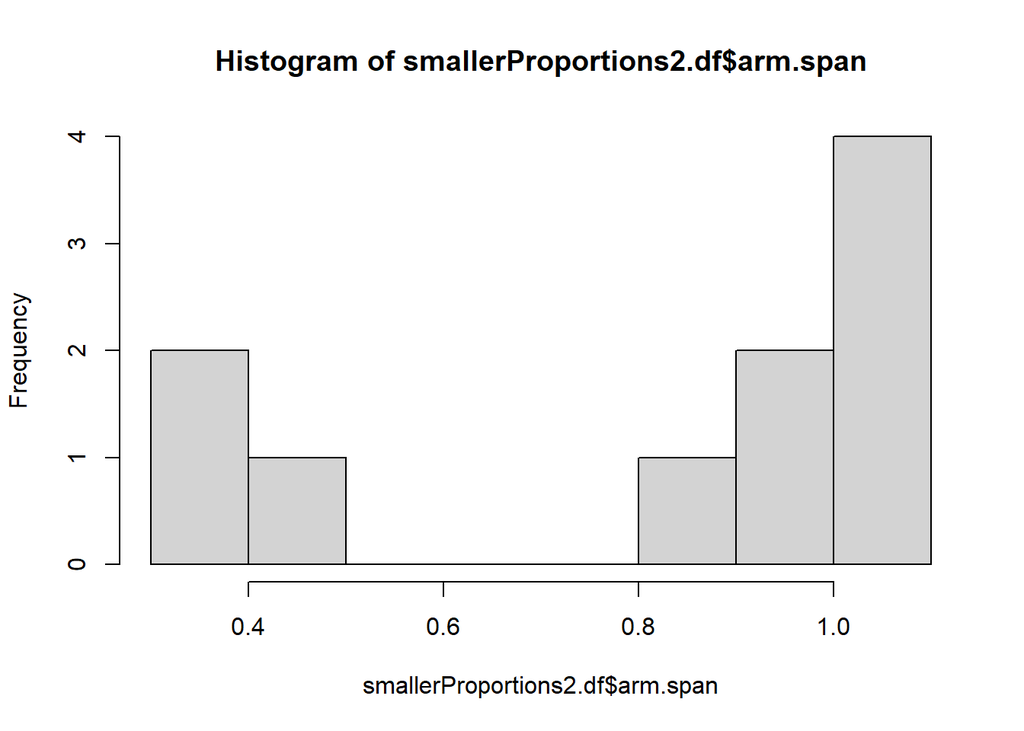

```r
hist(smallerProportions2.df$arm.span)
```